# Shifting News Markets Induced by a Decling in Advertising Revenue, a Reproduction of ‘Newspapers in Times of Low Advertising Revenues’ by Charles Angelucci and Julia Cagé

Yitian Zhao

22 December 2020

Abstract

With the rise of the internet and a shift in consumer behaviour headed towards digital platforms, the newspaper industry is worried about its ability to produce high-quality journalism with the decrease in advertising revenue. We are looking to recreate and investigate the findings of Charles Angelucci and Julia Cagé in their paper as they construct a dataset analyzing the effects on the French newspaper industry as advertising shifts towards French television between 1960 to 1974. We see that this a nearly parallel shift with the digitalization of advertising today as only the newspapers ad revenue is directly impacted while their costs, productivity, and readership remain under their control. As the study reveals that newspapers ended up playing a smaller role in delivering significant journalistic content in the 1960s, it goes into question how the industry will keep afloat as income keeps decreasing and journalism shifts towards other platforms.  
**Keywords: newspaper advertising, advertising revenue, ordinary least squares regression, journalism**

# Introduction

Inspired by Charles Angelucci and Julia Cagé’s “Newspapers in Times of Low Advertising Revenues”, we are looking to recreate their results investigating the effects on journalist employment, news quantity, and newspapers pricing that a lowered advertising revenue has on both national and local French newspaper companies.

In the modern time period where the Internet and social media dominate as news platforms, we are interested in how changing consumer preferences and productivity due to digitalization has overall negatively impacted the newspapers industry. Factors such as how advertisers are generally moving towards online platforms away from newspapers impact revenue generated from ads within the market and the shift in the income fundamentally requires a refocus in costs for newsrooms and journalists if the industry hopes to survive. The framework in which these relationships are analyzed is through a model where a newspaper is in control of price rates with both advertisers and its reader audience. It is taken into account that different readers prefer different amounts and variety of journalistically intensive content and that the journalistic content written has a direct positive correlation to costs for the newspaper. This framework allows for the analysis of how these factors come into play ultimately with advertising revenue as well as each other. It predicts that a decrease in advertising revenue leads to a shift in the content and readerbase where less journalistically intensive content is produced and the newspaper price drops catered towards an audience less focused on significant and meaningful news.

It is not the first time that the newspaper industry has had to compete with sources of news moving to a more advanced technological platform. We follow Angelucci and Cagé’s method to investigate how the predictions hold up against datasets built from information on French local and national newspapers and television between 1960 to 1974. As this time period was when technological advancements made it viable for televisions to be mass produced and affordable for families, it raised the opportunity for advertising companies to move to another platform and focus their efforts there which meant less resources invested into conventional newspaper ads. The introduction of television ads did not directly impact the costs and productivity of the newspaper industry as they only directly affected the advertising portion which provides a similar setting where cost, productivity, and readership is still under the control of the newspaper companies and will likely be reorganized in order to address a decreasing advertising revenue.

# Data

The data we are using is the same data collected by Angelucci and Cagé which is a data set on national and local French newspapers taken from 1960 to 1974. This is newspaper data that they have gathered from various historical sources that is now compiled into a digital format.

The information on prices, revenues, and circulation was collected from the French Ministry of Information’s records in the National archives as they required newspapers to report annually their revenues and prices. It is here where the information on the unit price, subscription price (annual subscription price divided by number of issues within the year), advertising revenues, sales revenues, number of issues, and information on circulation of unit buyers and subscription buyers is found. Their data set consists of samples of 68 local daily newspaper companies and 12 national daily newspaper companies. These samples represent a large portion of the local newspaper industry and the entire national newspaper industry during that time period.

Data on the journalists themselves was collected through “Commission de la carte d’identité des journalistes professionnels” (CCIJP) which is the organization that issues press cards to journalists. According to French regulations, media companies are not allowed to employ professional journalists without press cards for longer than 3 months. Journalists must also renew their press card annually. Data for this category was collected for 63/68 of the local newspapers and 11/12 of the national newspapers. Journalist information includes the number of journalists at a given newspaper company per year and their monthly salary. Data on journalists working for the French television and radio broadcasting agency (ORTF) was also collected for the years 1960, 1964-1971, and 1974. Similar to newspaper journalists, television journalists also require a press card to be employed.

Advertising revenues are affected by changing advertising prices and/or changing advertising quantities. Data is collected for both of these factors as we hope to see the effects of both on revenue. According to Angelucci and Cagé, the main source for gathering information on advertising prices is the official list price per column inch of advertising space from “Tarif Media,” an annual publication that provides information regarding advertising rates. As rates differ depending on the page which an ad is placed, the single rate they decided to use is for front page ads only as they have the most observations for it. A disadvantage of this method is that the rates are frequently discounted so the actual transaction price is lower. To combat this, another source of measuring prices comes from taking the total advertising revenue to be divided by the newspaper circulation. The amount of ads per issue comes from copies available in the French National Library providing the total number of ads and proportion of ads in the newspaper.

By investigating the newspapers’ contents, Angelucci and Cagé were also able to determine the amount of space dedicated to news. Changes in the content were analyzed through in 37 of the local newspapers and all of the national newspapers in the sample. The share of hard news and soft news stories were computed in each annual March issue in the 3rd week from 1964 to 1972.

Taking information from the Centre d’Etude des Supports de Publicité (CESP), Angelucci and Cagé were able to obtain data on readers’ characteristics. The CESP is an organization comprised of the biggest advertising businesses and thye produce reports on newspaper readers every 5 years from 1957 to 1967 and yearly beginning 1968. Data on their survey responses is included for the years 1957, 1962, 1967-1970, 1972, and 1974.

# Model

```
## [1] "Table 1"
```

|  | Subscription price | Unit price | Circulation | Share of sub | Revenue from sales |
| --- | --- | --- | --- | --- | --- |
| after_national1 | -0.04 * | 0.06 ** | -0.06 ** | 0.19 *** | -0.06 * |
|  | (0.02) | (0.02) | (0.02) | (0.03) | (0.03) |
| year | 0.05 *** | 0.05 *** | 0.01 *** | -0.01 *** | 0.05 *** |
|  | (0.00) | (0.00) | (0.00) | (0.00) | (0.00) |
| N | 1044 | 1063 | 1070 | 1072 | 1046 |
| R2 | 0.88 | 0.87 | 0.99 | 0.97 | 0.99 |
| logLik | 882.14 | 907.28 | 759.57 | 321.91 | 451.11 |
| AIC | -1600.28 | -1650.57 | -1355.15 | -477.81 | -738.22 |
| *** p < 0.001; ** p < 0.01; * p < 0.05. |  |  |  |  |  |

```
## [1] "Table 2"
```

|  | Ad. rev. | Ad rev. div. circ. | Ad price | Ad space |
| --- | --- | --- | --- | --- |
| after_national1 | -0.23 *** | -0.15 *** | -0.31 *** | 0.01 |
|  | (0.03) | (0.03) | (0.07) | (0.05) |
| year | 0.05 *** | 0.04 *** | 0.04 *** | 0.02 *** |
|  | (0.00) | (0.00) | (0.00) | (0.00) |
| N | 1052 | 1048 | 809 | 1046 |
| R2 | 0.99 | 0.90 | 0.89 | 0.72 |
| logLik | 345.34 | 449.52 | -277.71 | -164.01 |
| AIC | -526.68 | -735.05 | 705.43 | 478.02 |
| *** p < 0.001; ** p < 0.01; * p < 0.05. |  |  |  |  |

```
## [1] "Table 3"
```

|  | Number of journalists | Average payroll | Number of pages | Newshole | Share of hard news front page |
| --- | --- | --- | --- | --- | --- |
| after_national1 | -0.20 *** | 0.06 | -0.02 | -0.04 | -0.06 |
|  | (0.03) | (0.05) | (0.02) | (0.02) | (0.04) |
| year | 0.04 *** | 0.03 *** | 0.03 *** | 0.03 *** | 0.00 |
|  | (0.00) | (0.00) | (0.00) | (0.00) | (0.00) |
| N | 1065 | 723 | 1046 | 1046 | 418 |
| R2 | 0.98 | 0.56 | 0.93 | 0.90 | 0.75 |
| logLik | 328.61 | 12.15 | 816.27 | 741.15 | 138.62 |
| AIC | -503.21 | 81.71 | -1482.54 | -1332.30 | -177.23 |
| *** p < 0.001; ** p < 0.01; * p < 0.05. |  |  |  |  |  |

```
## [1] "Table 4"
```

|  | No diploma | Primary education | Secondary education | Professional education | Senior execs | Employees | Laborers |
| --- | --- | --- | --- | --- | --- | --- | --- |
| after_national1 | 0.52 | 1.78 ** | -2.26 *** | 0.14 | -1.01 ** | -8.73 *** | 4.83 *** |
|  | (0.71) | (0.69) | (0.64) | (0.58) | (0.37) | (0.61) | (0.85) |
| year | -0.12 * | -1.29 *** | 0.58 *** | 0.82 *** | 0.08 ** | -0.39 *** | -0.32 *** |
|  | (0.05) | (0.05) | (0.04) | (0.04) | (0.02) | (0.04) | (0.06) |
| N | 413 | 413 | 413 | 413 | 413 | 413 | 413 |
| R2 | 0.36 | 0.96 | 0.79 | 0.94 | 0.96 | 0.77 | 0.90 |
| logLik | -1053.11 | -1042.43 | -1015.14 | -975.28 | -784.40 | -992.58 | -1132.09 |
| AIC | 2188.22 | 2166.86 | 2112.29 | 2032.55 | 1650.80 | 2067.15 | 2346.19 |
| *** p < 0.001; ** p < 0.01; * p < 0.05. |  |  |  |  |  |  |  |

Our OLS model equation is:

$$\begin{equation}
ln(y_{n,t}) = \beta_0 + \beta_1(National Dummy * 1967 Onward Dummy) + \lambda_n + \gamma_y +\epsilon
\end{equation}$$

We use our model to identify changes in our interested variables as we build a relationship for them with respect to the introduction of television and differing years. Our independent variables all relate to identifying how ad revenue, cost and price, and readership is affected. Changes in our chosen variables depict a picture of how the decline in ad revenue has affected the industry over time and how changes are being made to adapt to changing consumer behaviors. With respect to the newspaper dataset, we calculate the revenue share and convert certain variables into factors to produce our desired results.

When considering other models that could potentially be used, we decided to choose using a original least squares linear model since since we are looking to model data a variety of variables using the same independent variables. As we seek to observe the changes in variables such as ad revenue, journalist payroll, ad space, etc. it is a good idea to model them with a simple OLS regression we get their results with respect to fixed effects in our year and televised ad variables. The change in the beta coefficients measure the yerly effect of our outcomes with the presence of televised advertisements. When considering an alternative such as Bayesian regression, it is harder to make a strong conclusion from our model only using non-informative priors as we do not have priors for our data.

As we look at each area of study: readership, newspaper quality, and changes in price/cost, we measure certain dependent variables as a way to organize our findings. With readership, the intuitive mindset would be to investigate if readers of newspapers past the introduction of televised ads belong to a less affluent group as televisions are still settling into affordable price points for the average household. Here we would measure readers’ education and occupation with our model as a way to explore this. When defining a way to measure the quality of a paper, we decide to look into the amount of space reserved for ads and for content as well as observe the number of journalists employed and their pay grade. The assumption here is that the number or journalists and amount of space reserved for news has a positive correlating relationship with newspaper quality and we use this to determine if the paper is composed to journalistically intensive content or more catered to less significant soft news. Lastly, we investigate the subscription price, unit price, and circulation of newspapers to explore how they perform in terms of sales and use these results in conjunction with the other aspects to make a conclusion of how newspapers are being produced and who they are catered towards.

# Results

Looking at Table 2, we see that there is a 23 percent drop in advertising revenue as ads shift towards television in in this time period. This decrease is brought about by the trend of ad pricing for newspaper decreasing over the years as television begins to hold a bigger portion over the advertising market. We see that there is a steep 31 percent drop in ad pricing meaning significantly less revenue on that front. There is still a 15 percent decrease even when the revenue is normalized by circulation. As there isn’t a very significant change in the quantity of ads put up, the final assessment of this information is that there remains a heavy significant loss of income from the ads.

We also consider how the change the decrease in ad revenue affects the pricing of newspapers towards readers. In Table 1, we see that there is a 4 percent decrease of subscription pricing for national newspapers compared to local newspapers. This is accompanied by a 6 percent increase in the unit cost which shows a significant increase in the price discrimination between the pricing strategies. Circulation also shows a decrease by 6 percent however there exists a much larger share in subscribers to the newspaper as it has increased by 19 percent. Unfortunately this does not make up the decrease as revenue from sales is ultimately shown to have decreased by 6 percent.

Following Angelucci and Cage’s methods, we explore the quality of the newspapers by measuring the number of journalists employed and the newshole, which is the amount of space on the newspaper devoted to content rather than ads. The shift in advertisement introduces a 20 percent decrease in the number journalists employed while the average payroll has increased by 6 percent. The number of pages, newshole, and share of hard news present on front pages all decrease by small amount of 2 percent, 4 percent, and 6 percent respectively. These figures are not large enough to suggest major changes in newspaper content and it is not true to assume they encompass all aspects of newspaper quality. However, the fact that a sizeable portion of journalists leaving while the amount of content remains the same suggests that there should be a decrease in the amount of journalistically intensive content.

The third variable readership also changes as we study it with respect to the decrease in ad revenue. Since the data is available for only 38 newspapers in total (with all the national papers), the conclusions drawn aren’t as strong when compared to other variables. Table 4 contains information about readers’ education status and occupation as we see a trend that the audience is comprised of less employees and more laborers at the largest figures of a decrease of 8.73 percent and an increase of 4.83 percent respectively.

# Discussion

French television was state owned from 1945 to 1981 by the national agency “Office de Radiodiffusion-Télévision Française” (ORTF). The ORTF was non-profit a funded by revenue from television license fees. There was only a single channel available until 1963 with a second TV channel introduced in 1964 and a third one in 1972. The French government introduced advertising on television in 1967. It was argued that the ORTF needed new sources of revenues to continue developing the second and third TV channels. The first television advertisement was braodcasted in 1968. Content broadcasted on television was also mostly national. Left-leaning political parties and newspapers were strongly against the introduction of advertising to television. Bills were introduced to ban commercial advertising on television by justified saying it would lead to a decrease in the quality of television content. More importantly is the idea that the reform would also lead to a decrease in newspaper advertising revenues. The French Press estimated that the press would lose between 40 percent and 50 percent of its advertising revenues which is between 20 percent and 40 percent of total revenues.

At first the number of minutes of advertising per day allowed on television was heavily regulated and a low amount. It was limited to 2 minutes per day in 1968. Advertising revenues generated by the ORTF increased by €82.3 million from 1967 to 1968 and by €216 million from 1968 to 1969 and made up 22 percent of the ORTF’s total revenues by 1971. While the small quantity of advertising the reform brought in most likely didn’t significantly affect the consumer preferences of TV viewers and newspaper readers, it generated large enough revenues for the ORTF. Moving forward, the decrease in ad revenue for newspapers will be used to study the change in journalist employment, content shifts, and pricing. As the change in the advertising industry was sudden, ad pricing was high in accordance with the high demand for the limited advertising times on the air. We see in Figure 3 that the television ad revenue generated over 500 million euros within the span of the 6 years it was introduced. A consequence of this resulted in the decrease of ad revenue for national newspapers at them time where total advertising revenues of national daily newspapers decreased by €49.5 million from 1967 to 1968 even in a time period when the advertising industry went through a phase of expansion from 1967 to 1974. However, local newspaper revenue increased during this time period as seen in Figure 2.

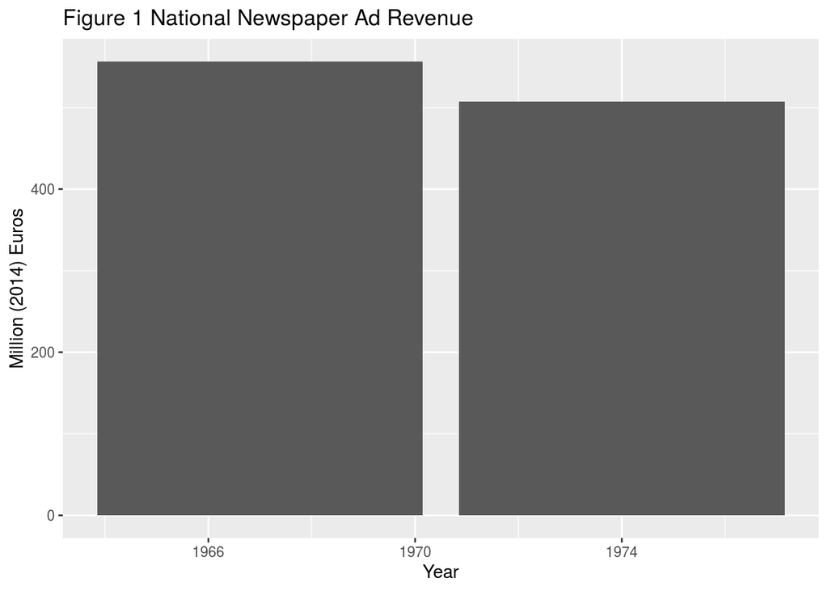

```r
# Ad revenue comaprisons
ad_revenue <- Micro_Descriptive_evidence_advertising_industry
ggplot(ad_revenue, aes(x = year, y = adpqn)) + geom_col() + xlab("Year") + ylab("Million (2014) Euros") + ggtitle("Figure 1 National Newspaper Ad Revenue")
```

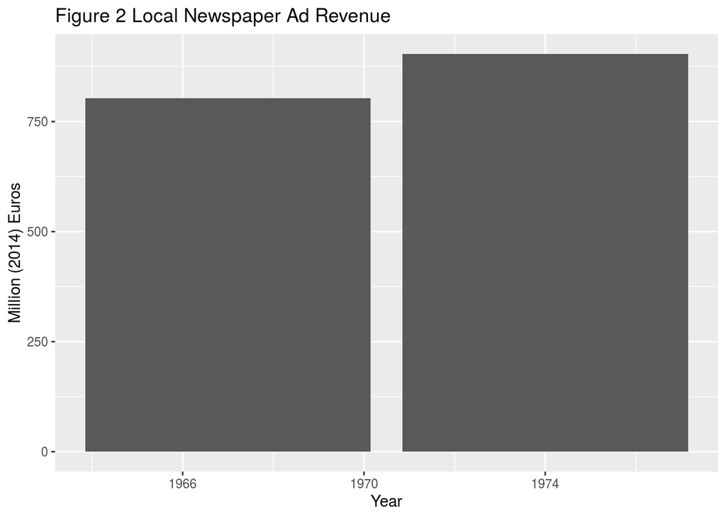

```r
ggplot(ad_revenue, aes(x = year, y = adpqr)) + geom_col() + xlab("Year") + ylab("Million (2014) Euros") + ggtitle("Figure 2 Local Newspaper Ad Revenue")
```

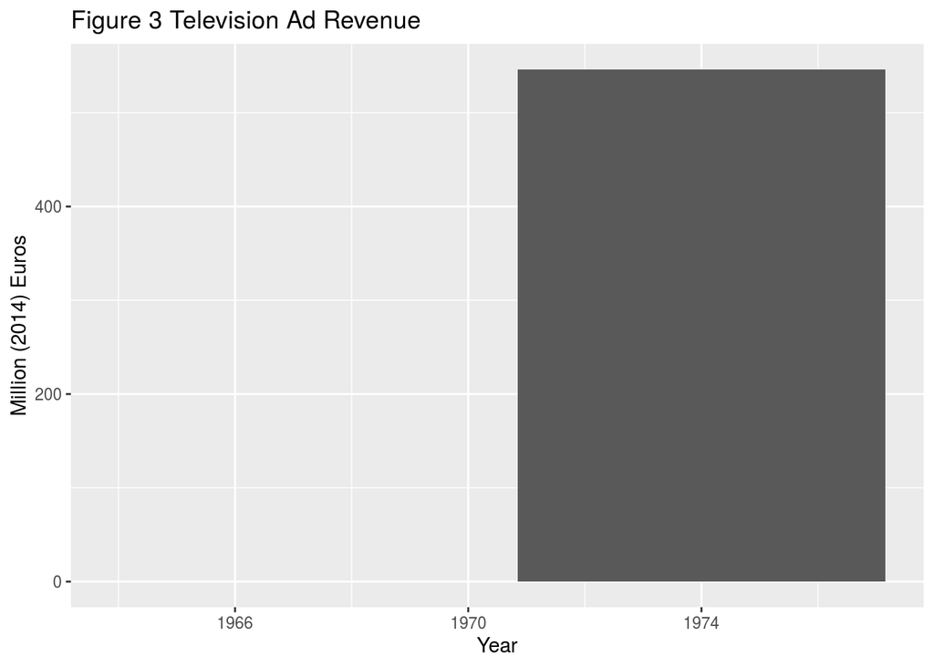

[figure not shown]

[figure not shown]

[figure not shown]

[figure not shown]

```r
ggplot(ad_revenue, aes(x = year, y = adtv)) + geom_col() + xlab("Year") + ylab("Million (2014) Euros") + ggtitle("Figure 3 Television Ad Revenue")
```

When looking at both the flat and percent decreases in Figures 1,2,4, and 5, it is evident that the shift in advertising caused a bigger decrease in the revenues of national newspapers rather than local ones. This is because national television broadcasts directly compete with national newspapers for brand advertisements meant to be distributed on a nation wide scale and is also heavily relied on by national newspapers before television ads. Local ads on the other hand, are less affected by national television broadcasts as these ads are meant to reach a smaller area.

The decrease in advertising revenues and advertising prices can be explained by the arrival of a new advertising platform. We see there is an absence of change in the quantity of advertising despite the lower advertising prices. There is also a decrease in the number of journalists employed along with the absence of change in the newshole which imply a shift toward less journalistically intensive content. Newspapers likely decreased the average quality of their stories as in the same type of journalistic content but less writers working on them. Another option would be including more soft news instead of hard news. This decrease in the production of journalistically intensive content is supported by results found in our model predictions. Providing quality content raises costs but is correlated to increasing the size of the readership who are more attractive to advertisers. This also explains how when advertising revenues drop, newspapers have less incentive to invest in news quality.

Another change that a drop in ad revenue brings is the price discrimination between subscription and unit prices. Investigation of the relationship between the price gap and advertising revenues shows that a drop in advertising revenues increases the price gap. We see that national newspapers decrease their subscription price while the intuitive approach might be to increase prices on the readers’ end. While we showed that newspapers had incentives to reduce their production of quality content when faced with lower advertising revenues, it is the shift in readerbase as well that leads to this decision in the subscription price change. A less affluent readerbase is catered towards in a time of ad revenue drop so a loyal customer base consisting of less affluent individuals requires a lower price to maximize sales.

Neither local newspapers nor national newspapers held a monopoly over the market. However there still remain a difference in their comparisons especially as local newspapers were much less affected by the introduction of television ads. It becomes difficult to determine which of the national or local newspaper market is more competitive. There are also several factors which the result in bias and potentially affect the findings. Subsidies would be one such example. Daily newspapers were subsidized through reduced VAT rates, subsidized paper prices, and reduced rates for their delivery services. This applied to both local and national newspapers until 1973. With this in mind, both local and national newspapers relied on postal services to deliver subscriptions, but national newspapers needed to be delivered within a wider reach from their printing press to areas across the country. This may raise concerns about train delivery and postage rates during the time. Subsidies were also introduced to newspapers with low advertising revenues and/or low circulation in 1973. Another factor would be any special circumstances with the French newspaper industry and the economics of journalism at the time. It is assumed that the shift of advertising towards new platforms is univerisal outside of France while special details such as the advertising regulations on television had a huge impact on the ad revenue stream of newspaper companies.

When compared to today, the migration towards moving news online evokes a another deep issue in the newspaper industry as ad revenue continues to move away to yet another platform. We now witness more fundamental changes within how newspapers are produced as the decrease in costs by using the Internet has further saturated the market. It becomes more difficult to profit off of online news content while it is more accessible than ever.

# References

- R Core Team (2020). R: A language and environment for statistical computing. R, Foundation for Statistical Computing, Vienna, Austria. URL, https://www.R-project.org/.
- Wickham et al., (2019). Welcome to the tidyverse. Journal of Open Source Software, 4(43), 1686, https://doi.org/10.21105/joss.01686
- Hadley Wickham and Evan Miller (2020). haven: Import and Export ‘SPSS’, ‘Stata’ and ‘SAS’ Files. R package version 2.3.1. https://CRAN.R-project.org/package=haven
- Hadley Wickham, Romain François, Lionel Henry and Kirill Müller (2020). dplyr: A Grammar of Data Manipulation. R package version 1.0.2. https://CRAN.R-project.org/package=dplyr
- H. Wickham. ggplot2: Elegant Graphics for Data Analysis. Springer-Verlag New York, 2016.
- Charles Angelucci and Julia Cagé (2019). Newspapers in Times of Low Advertising Revenues. URL, https://doi.org/10.1257/mic.20170306
- Yihui Xie (2016). bookdown: Authoring Books and Technical Documents with R Markdown. Chapman and Hall/CRC. ISBN 978-1138700109
- David Hugh-Jones (2020). huxtable: Easily Create and Style Tables for LaTeX, HTML and Other Formats. R package version 5.1.1. https://hughjonesd.github.io/huxtable/
- Hadley Wickham and Dana Seidel (2020). scales: Scale Functions for Visualization. https://scales.r-lib.org, https://github.com/r-lib/scales.
- Kirill Müller (2020). here: A Simpler Way to Find Your Files. https://here.r-lib.org/, https://github.com/r-lib/here.